# parse_text inside longpca

```r
library(dplyr)
library(longpca)
```

This document shows how you can use `parse_text` inside the function `make_interaction_model`. Recall that the basic use of `make_interaction_model` in the flights data:

```r
library(nycflights13)
formula =  ~ (month & day)*(dest)
im = make_interaction_model(formula, flights)
# pcs = pca(im, k = 6)
```

In this example, the formula is `~ (month & day)*(dest)`. So, the rows are indexed by the unique values of `month` and `day` and the columns are indexed by the unique values of `dest`.

```r
im$row_universe
```

```
#> # A tibble: 365 × 4
#>    month   day     n row_num
#>    <int> <int> <int>   <int>
#>  1    11    27  1014       1
#>  2     7    11  1006       2
#>  3     7     8  1004       3
#>  4     7    10  1004       4
#>  5    12     2  1004       5
#>  6     7    18  1003       6
#>  7     7    25  1003       7
#>  8     7    12  1002       8
#>  9     7     9  1001       9
#> 10     7    17  1001      10
#> # ℹ 355 more rows
```

```r
im$column_universe
```

```
#> # A tibble: 105 × 3
#>    dest      n col_num
#>    <chr> <int>   <int>
#>  1 ORD   17283       1
#>  2 ATL   17215       2
#>  3 LAX   16174       3
#>  4 BOS   15508       4
#>  5 MCO   14082       5
#>  6 CLT   14064       6
#>  7 SFO   13331       7
#>  8 FLL   12055       8
#>  9 MIA   11728       9
#> 10 DCA    9705      10
#> # ℹ 95 more rows
```

If our data contains sentences, then the “unique values” need to first be parsed/extracted. For example, loaded into `longpca` is a toy data set `all_packages`. It is about 20000 rows. Each row gives information about one R package.

```r
# you can get a fresh version here:
# all_packages = available.packages() %>% as_tibble()
all_packages |> select(Package,  Imports)
```

```
#> # A tibble: 20,319 × 2
#>    Package       Imports
#>    <chr>         <chr>
#>  1 A3            <NA>
#>  2 AalenJohansen <NA>
#>  3 AATtools      magrittr, dplyr, doParallel, foreach
#>  4 ABACUS        ggplot2 (>= 3.1.0), shiny (>= 1.3.1),
#>  5 abasequence   <NA>
#>  6 abbreviate    <NA>
#>  7 abc           <NA>
#>  8 abc.data      <NA>
#>  9 ABC.RAP       graphics, stats, utils
#> 10 ABCanalysis   plotrix
#> # ℹ 20,309 more rows
```

Notice how the column `Imports` gives a “csv” of other packages. We can “extract” these values with `parse_text = TRUE`:

```r
im_imports = make_interaction_model(~Package*Imports, tib = all_packages, parse_text= TRUE)
im_imports$row_universe
```

```
#> # A tibble: 20,319 × 3
#>    Package                n row_num
#>    <chr>              <int>   <int>
#>  1 Seurat                64       1
#>  2 tidyverse             60       2
#>  3 radiant.data          58       3
#>  4 radiant.model         58       4
#>  5 SSDM                  55       5
#>  6 BasketballAnalyzeR    53       6
#>  7 tRigon                49       7
#>  8 AFM                   48       8
#>  9 dextergui             48       9
#> 10 proteus               48      10
#> # ℹ 20,309 more rows
```

```r
im_imports$column_universe
```

```
#> # A tibble: 6,230 × 4
#>    from_text token        n col_num
#>    <chr>     <chr>    <int>   <int>
#>  1 Imports   stats     5442       1
#>  2 Imports   utils     3423       2
#>  3 Imports   dplyr     3299       3
#>  4 Imports   methods   3210       4
#>  5 Imports   ggplot2   3135       5
#>  6 Imports   rcpp      2548       6
#>  7 Imports   rlang     2172       7
#>  8 Imports   graphics  2158       8
#>  9 Imports   magrittr  1954       9
#> 10 Imports   stringr   1698      10
#> # ℹ 6,220 more rows
```

Under the hood, this calls `tidytext::unnest_tokens` to convert `Imports` into a “bag-of-words”. So, the columns are now indexed by the unique packages that are imported. There are 20,319 total `Packages` in `all_packages` and each one forms a row in `im_imports`. Only 6,230 of these packages have been imported by another package. Each of these forms a column in `im_imports`.

Additional arguments to `make_interaction_model` are passed off to `tidytext::unest_tokens`. For example, by default it puts the imported packages into lower case. We can turn that off…

```r
im_imports = make_interaction_model(~Package*Imports, tib = all_packages, parse_text= TRUE, to_lower = FALSE)
im_imports$column_universe
```

```
#> # A tibble: 6,230 × 4
#>    from_text token        n col_num
#>    <chr>     <chr>    <int>   <int>
#>  1 Imports   stats     5442       1
#>  2 Imports   utils     3423       2
#>  3 Imports   dplyr     3299       3
#>  4 Imports   methods   3210       4
#>  5 Imports   ggplot2   3135       5
#>  6 Imports   Rcpp      2548       6
#>  7 Imports   rlang     2172       7
#>  8 Imports   graphics  2158       8
#>  9 Imports   magrittr  1954       9
#> 10 Imports   stringr   1698      10
#> # ℹ 6,220 more rows
```

Notice how `Rcpp` in row 6 of the `$column_universe` was previously `rcpp` (lower case). You could parse a different variable instead. For example,

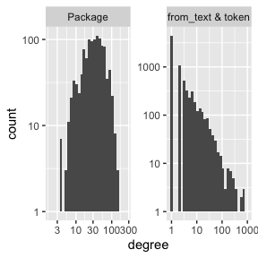

```
#> # A tibble: 6 × 3
#>   measurement     Package `from_text & token`
#>   <chr>             <dbl>               <dbl>
#> 1 number_of_items    1094                7878
#> 2 average_degree       38                   5
#> 3 median_degree        33                   1
#> 4 percent_le_1          0                  57
#> 5 percent_le_2          0                  71
#> 6 percent_le_3          0                  77
im_description$column_universe
#> # A tibble: 7,878 × 4
#>    from_text   token         n col_num
#>    <chr>       <chr>     <int>   <int>
#>  1 Description and        2571       1
#>  2 Description the        1999       2
#>  3 Description of         1388       3
#>  4 Description for        1350       4
#>  5 Description to         1104       5
#>  6 Description a          1013       6
#>  7 Description in          722       7
#>  8 Description functions   581       8
#>  9 Description data        541       9
#> 10 Description package     515      10
#> # ℹ 7,868 more rows
```

```r
im_description = make_interaction_model(~Package*Description, top_packages, parse_text = TRUE, to_lower= TRUE)
diagnose(im_description)
```

Here we see the stopwords. These will form high degree nodes in your `interaction_model` graph. A factor that loads heavily on these is often a factor that indicates “document length”.

You can also parse multiple columns with the `&`:

```r
im_imports_authors = make_interaction_model(~Package*(Imports&Author&Description&Title), tib = top_packages, parse_text = TRUE)
im_imports_authors$row_universe
```

```
#> # A tibble: 1,094 × 3
#>    Package             n row_num
#>    <chr>           <int>   <int>
#>  1 broom             671       1
#>  2 DescTools         562       2
#>  3 ff                488       3
#>  4 knitr             430       4
#>  5 ape               411       5
#>  6 spatstat          392       6
#>  7 spdep             381       7
#>  8 netmeta           346       8
#>  9 Seurat            339       9
#> 10 spatstat.linnet   333      10
#> # ℹ 1,084 more rows
```

```r
im_imports_authors$column_universe
```

```
#> # A tibble: 17,696 × 4
#>    from_text   token         n col_num
#>    <chr>       <chr>     <int>   <int>
#>  1 Author      ctb        2744       1
#>  2 Description and        2571       2
#>  3 Author      aut        2077       3
#>  4 Description the        1999       4
#>  5 Description of         1388       5
#>  6 Description for        1350       6
#>  7 Description to         1104       7
#>  8 Author      https      1048       8
#>  9 Description a          1013       9
#> 10 Author      orcid.org  1008      10
#> # ℹ 17,686 more rows
```

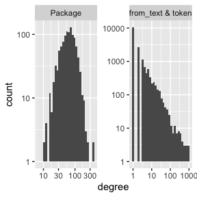

```
#> # A tibble: 6 × 3
#>   measurement     Package `from_text & token`
#>   <chr>             <dbl>               <dbl>
#> 1 number_of_items    1094               17696
#> 2 average_degree       70                   4
#> 3 median_degree        62                   1
#> 4 percent_le_1          0                  60
#> 5 percent_le_2          0                  75
#> 6 percent_le_3          0                  81
```

```r
diagnose(im_imports_authors)
```

Because it is so sparse, I’m going to use more bootstraps than default in `pick_dim`; 20 should be enough.

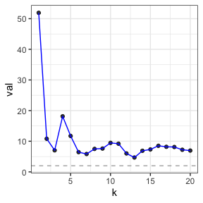

```r
eigcv = pick_dim(im_imports_authors, num_bootstraps = 20)
plot(eigcv)
```

```r
eigcv
```

```
#> Estimated graph dimension:    20
#>
#> Number of bootstraps:         20
#> Edge splitting probabaility:  0.1
#> Significance level:       0.05
#>
#>  ------------ Summary of Tests ------------
#>   k         z        pvals         padj
#>   1 51.913087 0.000000e+00 0.000000e+00
#>   2 10.815982 1.445902e-27 1.445902e-27
#>   3  7.036924 9.826501e-13 9.826501e-13
#>   4 18.131736 8.950800e-74 8.950800e-74
#>   5 11.725959 4.691617e-32 4.691617e-32
#>   6  6.445689 5.753838e-11 5.753838e-11
#>   7  5.837747 2.645575e-09 2.645575e-09
#>   8  7.504403 3.085462e-14 3.085462e-14
#>   9  7.613678 1.332018e-14 1.332018e-14
#>  10  9.456693 1.589183e-21 1.589183e-21
#>  11  9.196951 1.841244e-20 1.841244e-20
#>  12  6.021939 8.616988e-10 8.616988e-10
#>  13  4.688351 1.377077e-06 1.377077e-06
#>  14  6.885446 2.880339e-12 2.880339e-12
#>  15  7.318517 1.253630e-13 1.253630e-13
#>  16  8.513021 8.472960e-18 8.472960e-18
#>  17  8.184947 1.362114e-16 1.362114e-16
#>  18  8.121764 2.297284e-16 2.297284e-16
#>  19  7.220655 2.586879e-13 2.586879e-13
#>  20  6.957367 1.733451e-12 1.733451e-12
```

I’m going to pick 10 for convenience.

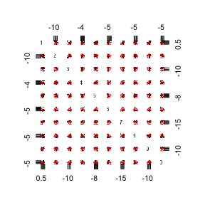

```r
pcs = pca(im_imports_authors, k = 10)
streaks(pcs)
```

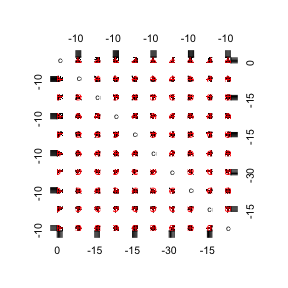

```r
streaks(pcs, "columns")
```

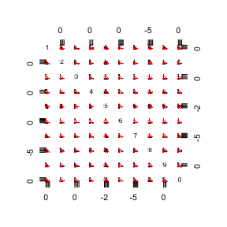

```r
spcs = rotate(pcs)
streaks(spcs)
```

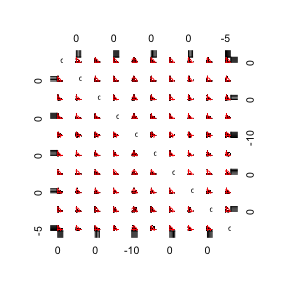

```r
streaks(spcs, "columns")
```

For example, the second rotated component looks to pick up the cluster of r packages for making html things:

```r
top(spcs, 2,keep_how_many = 15)
```

```
#> $top_rows
#> # A tibble: 15 × 2
#>    Package        vpc_02_rows
#>    <chr>                <dbl>
#>  1 shiny                15.5
#>  2 rmarkdown            12.3
#>  3 crosstalk             9.74
#>  4 leaflet.extras        7.08
#>  5 bookdown              7.00
#>  6 httpuv                6.61
#>  7 leaflet               6.54
#>  8 bslib                 6.05
#>  9 jquerylib             5.18
#> 10 fresh                 4.72
#> 11 reactable             4.65
```

[output cut: 29 more lines]